# Read_recorded_registerValues

```python
import sys
import getpass

if getpass.getuser() == "dv" and "/home/dv/pythonEnv/Notebook_Love/Scripts" not in sys.path:
    sys.path.append("/home/dv/pythonEnv/Notebook_Love/Scripts")
if getpass.getuser() == "love" and "/home/love/tofino-master/tofino-master-thesis/Current_project/Evaluation/Scripts/" not in sys.path:
    sys.path.append("/home/love/tofino-master/tofino-master-thesis/Current_project/Evaluation/Scripts/")
from configure_register_plot import StartPlot
```

## Evaluation

### 1. Time for ECDF read, invertion and write cycle. Table and counter size is varied.

- All combinations of:
  - m = {8,9,10,11,12,13}, represents table size.
  - c = {1024,2048,4096,8192,16384,32768}, represents counter size.
- For each combination do two variations:
  - Variation 1. Run for 10 seconds. Control Plane goes through the entirety of ECDF invertion cycle.
  - Variation 2. Run for 10 seconds. Control Plane skips everything except writing to the Data Plane (dummy values).
- Additionally:
  - Run traffic, 1 gold flow and 1 silver flow.
  - Set ECDF update timer to 0.
  - α is set to 0.3125 and β is set to 3.125.

(tests ending with _2 has the time for counter pull and write dummy values) (Try to draw all Ev1_m8 ... Ev1_m13 in the same graph)

Results

- Ev1
  - Ev1_m8
    - Ev1_m8_c1024, Ev1_m8_c1024_2
    - Ev1_m8_c2048, Ev1_m8_c2048_2
    - Ev1_m8_c4096, Ev1_m8_c4096_2
    - Ev1_m8_c8192, Ev1_m8_c8192_2
    - Ev1_m8_c16384, Ev1_m8_c16384_2
    - Ev1_m8_c32768, Ev1_m8_c32768_2

```
- Ev1_m9
    - Ev1_m9_c1024, Ev1_m9_c1024_2
    - Ev1_m9_c2048, Ev1_m9_c2048_2
    - Ev1_m9_c4096, Ev1_m9_c4096_2
    - Ev1_m9_c8192, Ev1_m9_c8192_2
    - Ev1_m9_c16384, Ev1_m9_c16384_2
    - Ev1_m9_c32768, Ev1_m9_c32768_2


- Ev1_m10
    - Ev1_m10_c1024, Ev1_m10_c1024_2
    - Ev1_m10_c2048, Ev1_m10_c2048_2
    - Ev1_m10_c4096, Ev1_m10_c4096_2
    - Ev1_m10_c8192, Ev1_m10_c8192_2
    - Ev1_m10_c16384, Ev1_m10_c16384_2
    - Ev1_m10_c32768, Ev1_m10_c32768_2


- Ev1_m11
    - Ev1_m11_c1024, Ev1_m11_c1024_2
    - Ev1_m11_c2048, Ev1_m11_c2048_2
    - Ev1_m11_c4096, Ev1_m11_c4096_2
    - Ev1_m11_c8192, Ev1_m11_c8192_2
    - Ev1_m11_c16384, Ev1_m11_c16384_2
    - Ev1_m11_c32768, Ev1_m11_c32768_2


- Ev1_m12
    - Ev1_m12_c1024, Ev1_m12_c1024_2
    - Ev1_m12_c2048, Ev1_m12_c2048_2
    - Ev1_m12_c4096, Ev1_m12_c4096_2
    - Ev1_m12_c8192, Ev1_m12_c8192_2
    - Ev1_m12_c16384, Ev1_m12_c16384_2
    - Ev1_m12_c32768, Ev1_m12_c32768_2


- Ev1_m13
    - Ev1_m13_c1024, Ev1_m13_c1024_2
    - Ev1_m13_c2048, Ev1_m13_c2048_2
    - Ev1_m13_c4096, Ev1_m13_c4096_2
    - Ev1_m13_c8192, Ev1_m13_c8192_2
    - Ev1_m13_c16384, Ev1_m13_c16384_2
    - Ev1_m13_c32768 - tables too big to compile.
```

startCP(FileName = "Ev1_m13_c16384_2")

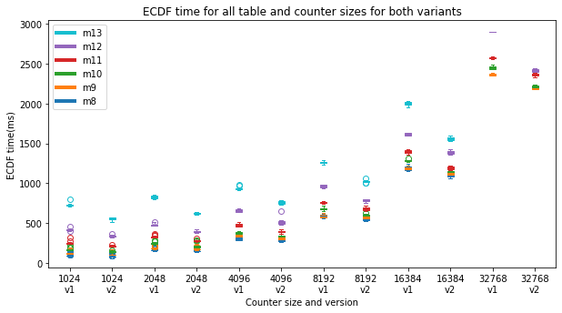

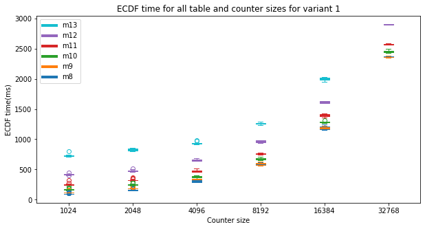

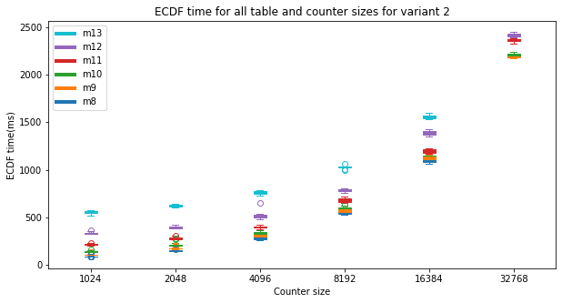

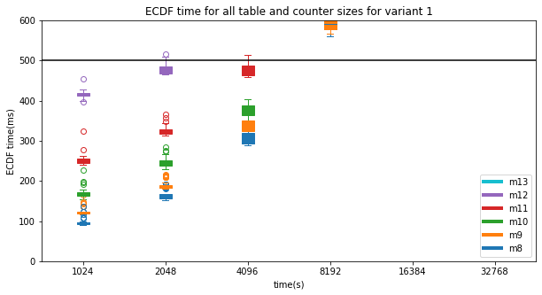

```python
save = True
version = "Evaluation_1"
names = ["Ev1"]
Order = 0
for name in names:
    Order = StartPlot(name, save, Order, version)
```

## Evaluation

### 2. ECDF of the Control Plane and the CTV in the Data Plane

- The following assumptions are made:
  - m represents table size.
  - c represents counter size.
  - The ECDF update timer in the Control Plane is set to 0.
  - α is set to 0.3125 and β is set to 3.125, unless otherwise specified.

The following tests are run:

- 1. Tests from overview test settings in Read_recorded_packetInformation.
- 1. Baseline.
- 1. Baseline with: CTV update interval to 5ms (equal to RTT) and 5 flows of each type added each 10s.
- 1. Baseline with: CTV update interval 1µs Reference delay 200µs 5 flows of each type added each 10s.

### 1. Overview tests.

```
1024
CTV: Proportion of 0s: 73.1701%, other: 26.8299%. Average = 7864.41, Median 0
```

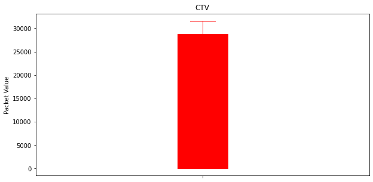

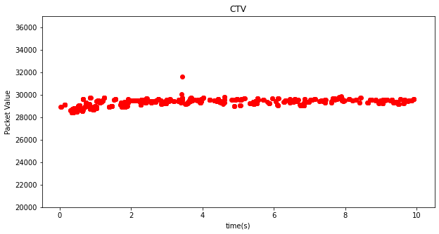

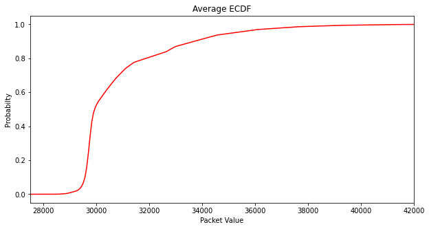

```python
name = "Overview_r2ms_10_m8_c10_t5ms"
version = "Evaluation_2"
save = False
Order = StartPlot(name, save, 0, version)
```

```
16384
CTV: Proportion of 0s: 60.0263%, other: 39.9737%. Average = 10651.5, Median 0
```

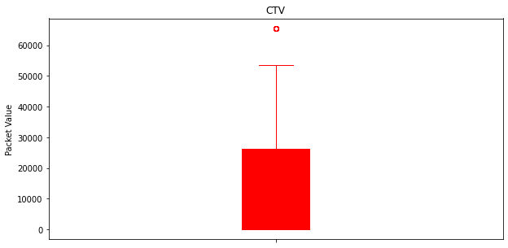

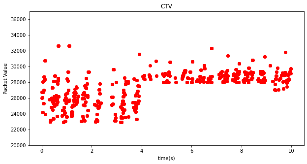

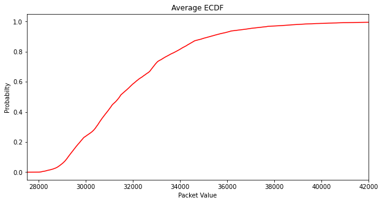

```python
name = "Overview_r200Mus_10_m13_c14_t5ms_v2"
version = "Evaluation_2"
save = False
Order = StartPlot(name, save, 0, version)
```

### 2. Baseline test.

- Name: "TEST_EvX_MC1_C1D1_P1_I1_T1_1"
- Starts with 10 flows of gold and 10 flows silver.
  - MC1: m = 8, c = 2^10.
  - C1D1: CTV update interval = 10µs, reference delay = 2ms.
  - P1: Port shaping 1gig.
  - I1: No added flows.
  - T1: Test time = 30s

```
CTV: Proportion of 0s: 33.3041%, other: 66.6959%. Average = 19735.7, Median 29632
```

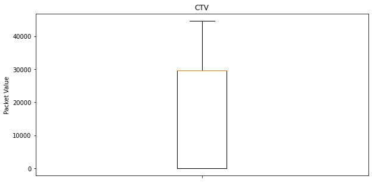

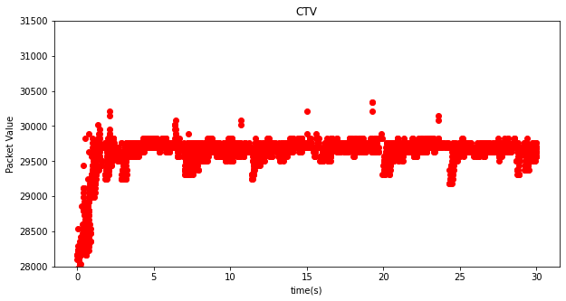

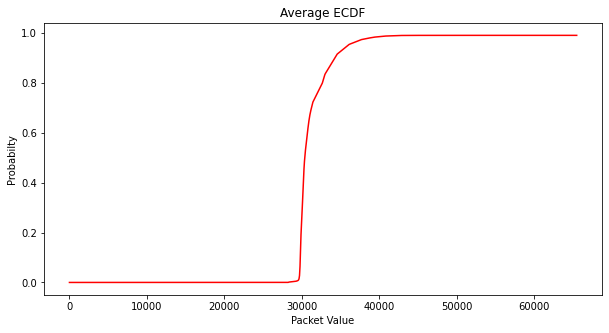

```python
save = False
version = "Evaluation_2"
name = "TEST_EvX_MC1_C1D1_P1_I1_T1_1"
Order = StartPlot(name, save, 0, version)
```

### 3. Baseline with:

#### CTV update interval to 5ms (equal to RTT).

#### 5 flows of each type added each 10s.

- Name: "TEST_EvX_MC1_C5D1_P1_I4_T1_1"
- Starts with 5 flows of gold and 5 flows silver.
  - MC1: m = 8, c = 2^10.
  - C5D1: CTV update interval = 5ms, reference delay = 2ms.
  - P1: Port shaping 1gig.
  - I4: Add 5g and 5s each 10s
  - T1: Test time = 30s

```
1024
CTV: Proportion of 0s: 79.0717%, other: 20.9283%. Average = 6175.34, Median 0
```

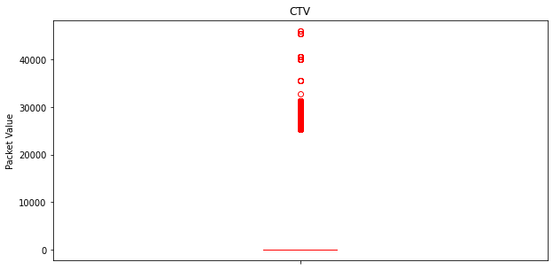

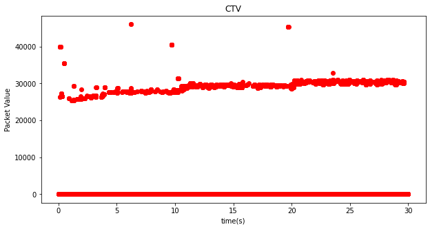

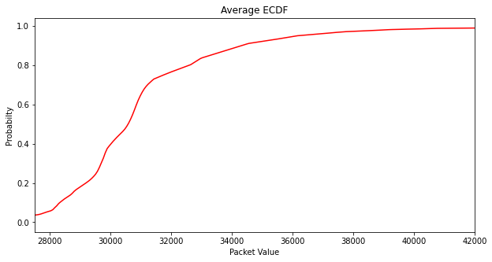

```python
save = False
version = "Evaluation_2"
name = "TEST_EvX_MC1_C5D1_P1_I4_T1_1"
Order = StartPlot(name, save, 0, version)
```

### 4. Baseline with:

#### CTV update interval 1µs

#### Reference delay 200µs

#### 5 flows of each type added each 10s.

- Name: "TEST_EvX_MC1_C2D2_P1_I4_T1_1"
- Starts with 5 flows of gold and 5 flows silver.
  - MC1: m = 8, c = 2^10.
  - C2D2: CTV update interval = 1µs, reference delay = 200µs.
  - P1: Port shaping 1gig.
  - I4: Add 5g and 5s each 10s
  - T1: Test time = 30s

```
1024
CTV: Proportion of 0s: 53.6984%, other: 46.3016%. Average = 14008.1, Median 0
```

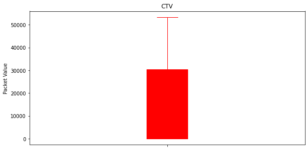

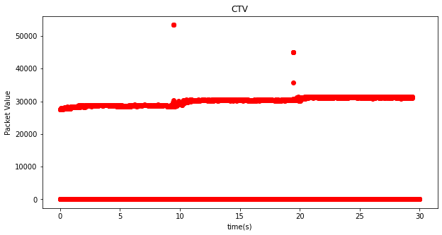

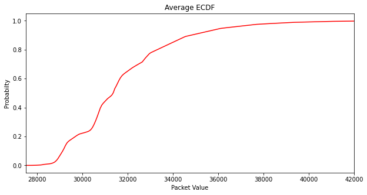

```python
save = False
version = "Evaluation_2"
name = "TEST_EvX_MC1_C2D2_P1_I4_T1_1"
Order = StartPlot(name, save, 0, version)
```